# STP598sta: Spatiotemporal Analysis

Multivariate Spatial Modeling

Shiwei Lan

Fall 2020

In lecture 6, we have learned multivariate spatial modeles for both point-referenced data and areal data. We will fit multivariate spatial models using `R` package `spBayes`.

```r
install.packages('spBayes')
install.packages('MBA')
install.packages('geoR')
install.packages('fields')
```

```r
library(spBayes)
library(MBA)
library(geoR)
library(fields)
```

## Multivariate spatial modeling for point-referenced data

### Data exploration

We investigate soil nutrient data which was collected at the La Selva Biologi- cal Station, Costa Rica, analyzed in greater detail by Guhaniyogi et al. (2013). Here, $n=80$ soil cores were sampled over a sparse grid centered on a more intensively sampled transect. Soil nutrient concentrations of calcium (Ca), potassium (K) and magnesium (Mg) were measured for each sample. These nutrient concentrations show a high positive correlation
$$\begin{bmatrix} 1 & & \\ 0.7 & 1 & \\ 0.7 & 0.8 & 1\end{bmatrix}$$
suggesting that we might build a richer model by explicitly accounting for spatial association among the $q = 3$ outcome variables.

Our objective is to predict these nutrients at a fine resolution over the study plot. Ultimately, posterior predictive samples will serve as input to a vegetation competition model. We begin by log transforming the response variables and taking a look at sample location across the study plot and then interpolating the outcome variables using the `mba.surf` function in the `MBA` package.

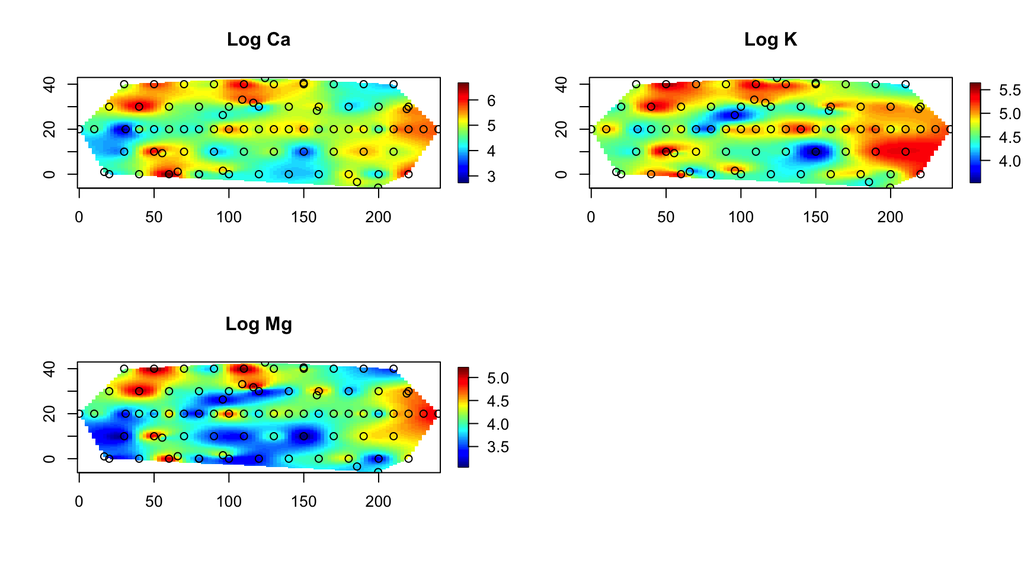

```r
### get data
dat <- read.table("CostaRica/T4.csv", header=T, sep=",")
coords <- as.matrix(dat[,c("X","Y")])
nut.names <- c("Ca","K","Mg")
log.nut <- log(dat[,nut.names])

### plot using mba.surf
par(mfrow=c(2,2))
for(i in 1:length(nut.names)){
  surf <- mba.surf(cbind(coords,data=log.nut[,i]), no.X=100, no.Y=100)$xyz.est
  image.plot(surf, main=paste("Log ",nut.names[i],sep=""))
  points(coords)
}
```

The figure depicts the nutrient concentration surfaces. These patterns can be more formally examined using empirical semivariograms. In the following code, we fit an exponential variogram model to each of the soil nutrients. In the plots of fitted variogram estimates, the upper and lower horizontal lines are the *sill* and *nugget*, respectively, and the vertical line is the effective range (i.e., that distance at which the correlation drops to 0.05).

Despite the patterns of spatial dependence, the variograms do not show much of a spatial process. Changing the number of bins (`bins`) and maximum distance considered (`max`) will produce effective spatial ranges of less than 20m for each of the nutrients; however, the signal is weak, likely due to the paucity of samples.

```
## variog: computing omnidirectional variogram
## variofit: covariance model used is exponential
## variofit: weights used: equal
## variofit: minimisation function used: nls
```

```
## variog: computing omnidirectional variogram
## variofit: covariance model used is exponential
## variofit: weights used: equal
## variofit: minimisation function used: nls
```

```
## variog: computing omnidirectional variogram
## variofit: covariance model used is exponential
## variofit: weights used: equal
## variofit: minimisation function used: nls
```

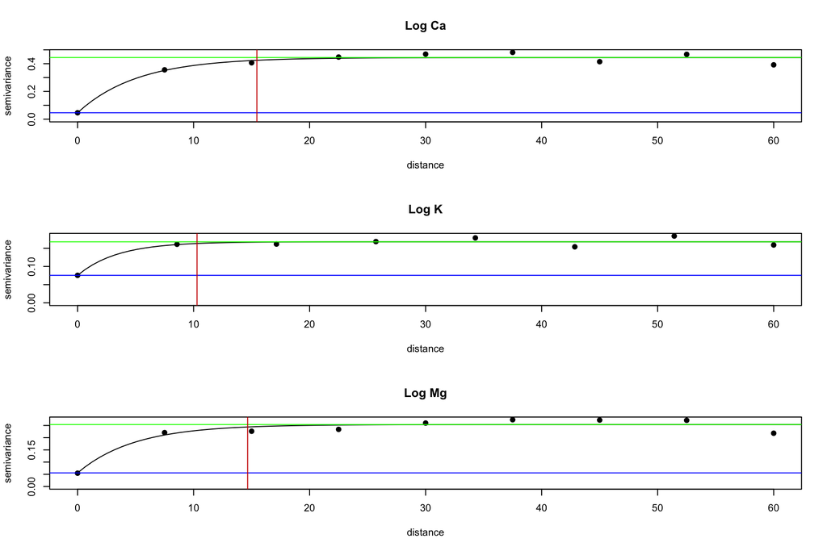

```r
### plot empirical semivariograms
max <- 0.25*max(as.matrix(dist(dat[,c("X","Y")])))
bins <- c(9,8,9)

par(mfrow=c(3,1))
for(i in 1:length(nut.names)){
  vario <- variog(coords=coords,data=log.nut[,i], uvec=(seq(0,max, length=bins[i])))

  fit <-variofit(vario, ini.cov.pars=c(0.3, 20/-log(0.05)), ##sigma^2 and 1/phi
                     cov.model="exponential", minimisation.function="nls", weights="equal")

  plot(vario, pch=19, main=paste("Log ",nut.names[i],sep=""))
  lines(fit)
  abline(h=fit$nugget, col="blue")
  abline(h=fit$cov.pars[1]+fit$nugget, col="green")
  abline(v=-log(0.05)*fit$cov.pars[2], col="red3")
}
```

### Fitting a Bayesian LMC model

We continue with fitting a multivariate regression that allows for spatial ($AA^T = K$) and non-spatial ($\Psi$) cross-covariance matrices. In the following code block we define the model parameters’ starting, tuning, and prior distribution, then call the `spMvLm` function in `spBayes` to estimate a simple Bayesian LMC (not spatially-varying). The sampler must compute Cholesky factorizations for $240 × 240$ dispersion matrices for each iteration.

```r
q <- 3
##Specify starting values and collect samples
A.starting <- diag(0.1,q)[lower.tri(diag(1,q), TRUE)]
Psi.starting <- rep(0.5, q)

A.tuning <- rep(0.0005,length(A.starting))
Psi.tuning <- rep(0.0005, q)

n.samples <- 10000

starting <- list("phi"=rep(3/20,q),"A"=A.starting,"Psi"=Psi.starting)
tuning <- list("phi"=rep(0.1,q),"A"=A.tuning, "Psi"=Psi.tuning)
priors <- list("phi.Unif"=list(rep(3/60,q), rep(3/10,q)), "K.IW"=list(q+1, diag(0.001,q)), "Psi.IG"=list(rep(2,q), c(0.05,0.08,0.05)))

m.1 <- spMvLM(list(Ca~1,K~1,Mg~1), coords=coords, data=log.nut,
              starting=starting, tuning=tuning, priors=priors,
              cov.model="exponential",  n.samples=n.samples, n.report=2000)
```

```
## ----------------------------------------
##  General model description
## ----------------------------------------
## Model fit with 80 observations.
##
## Number of covariates 3 (including intercept if specified).
##
## Using the exponential spatial correlation model.
##
## Number of MCMC samples 10000.
##
## Priors and hyperpriors:
##  beta flat.
##
##  K IW hyperpriors df=4.00000, S=
##  0.001   0.000   0.000
##  0.000   0.001   0.000
##  0.000   0.000   0.001
##
##  Diag(Psi) IG hyperpriors
##      parameter   shape   scale
##      Psi[1,1]    2.0 0.05
##      Psi[2,2]    2.0 0.08
##      Psi[3,3]    2.0 0.05
##
##  phi Unif hyperpriors
##      parameter   a   b
##      phi[1]      0.05000 0.30000
##      phi[2]      0.05000 0.30000
##      phi[3]      0.05000 0.30000
##
## -------------------------------------------------
##      Sampling
## -------------------------------------------------
## Sampled: 2000 of 10000, 20.00%
## Report interval Metrop. Acceptance rate: 56.05%
## Overall Metrop. Acceptance rate: 56.05%
## -------------------------------------------------
## Sampled: 4000 of 10000, 40.00%
## Report interval Metrop. Acceptance rate: 30.25%
## Overall Metrop. Acceptance rate: 43.15%
## -------------------------------------------------
## Sampled: 6000 of 10000, 60.00%
## Report interval Metrop. Acceptance rate: 27.90%
## Overall Metrop. Acceptance rate: 38.07%
## -------------------------------------------------
## Sampled: 8000 of 10000, 80.00%
## Report interval Metrop. Acceptance rate: 34.35%
## Overall Metrop. Acceptance rate: 37.14%
## -------------------------------------------------
## Sampled: 10000 of 10000, 100.00%
## Report interval Metrop. Acceptance rate: 33.80%
## Overall Metrop. Acceptance rate: 36.47%
## -------------------------------------------------
```

```r
##other starting
A.starting <- diag(0.05,q)[lower.tri(diag(1,q), TRUE)]
Psi.starting <- rep(0.1, q)

m.2 <- spMvLM(list(Ca~1,K~1,Mg~1), coords=coords, data=log.nut,
              starting=starting, tuning=tuning, priors=priors,
              cov.model="exponential",  n.samples=n.samples, n.report=2000)
```

```
## ----------------------------------------
##  General model description
## ----------------------------------------
## Model fit with 80 observations.
##
## Number of covariates 3 (including intercept if specified).
##
## Using the exponential spatial correlation model.
##
## Number of MCMC samples 10000.
##
## Priors and hyperpriors:
##  beta flat.
##
##  K IW hyperpriors df=4.00000, S=
##  0.001   0.000   0.000
##  0.000   0.001   0.000
##  0.000   0.000   0.001
##
##  Diag(Psi) IG hyperpriors
##      parameter   shape   scale
##      Psi[1,1]    2.0 0.05
##      Psi[2,2]    2.0 0.08
##      Psi[3,3]    2.0 0.05
##
##  phi Unif hyperpriors
##      parameter   a   b
##      phi[1]      0.05000 0.30000
##      phi[2]      0.05000 0.30000
##      phi[3]      0.05000 0.30000
##
## -------------------------------------------------
##      Sampling
## -------------------------------------------------
## Sampled: 2000 of 10000, 20.00%
## Report interval Metrop. Acceptance rate: 54.80%
## Overall Metrop. Acceptance rate: 54.80%
## -------------------------------------------------
## Sampled: 4000 of 10000, 40.00%
## Report interval Metrop. Acceptance rate: 41.65%
## Overall Metrop. Acceptance rate: 48.23%
## -------------------------------------------------
## Sampled: 6000 of 10000, 60.00%
## Report interval Metrop. Acceptance rate: 32.70%
## Overall Metrop. Acceptance rate: 43.05%
## -------------------------------------------------
## Sampled: 8000 of 10000, 80.00%
## Report interval Metrop. Acceptance rate: 45.25%
## Overall Metrop. Acceptance rate: 43.60%
## -------------------------------------------------
## Sampled: 10000 of 10000, 100.00%
## Report interval Metrop. Acceptance rate: 34.85%
## Overall Metrop. Acceptance rate: 41.85%
## -------------------------------------------------
```

```r
round(summary(m.1$p.theta.samples)$quantiles[,c(1,3,5)],3)
```

```
##           2.5%   50% 97.5%
## K[1,1]   0.005 0.355 0.552
## K[2,1]   0.011 0.187 0.302
## K[3,1]   0.018 0.272 0.404
## K[2,2]   0.021 0.104 0.172
## K[3,2]   0.032 0.148 0.224
## K[3,3]   0.060 0.214 0.325
## Psi[1,1] 0.039 0.082 0.579
## Psi[2,2] 0.038 0.052 0.282
## Psi[3,3] 0.025 0.042 0.304
## phi[1]   0.084 0.193 0.281
## phi[2]   0.051 0.147 0.294
## phi[3]   0.054 0.146 0.281
```

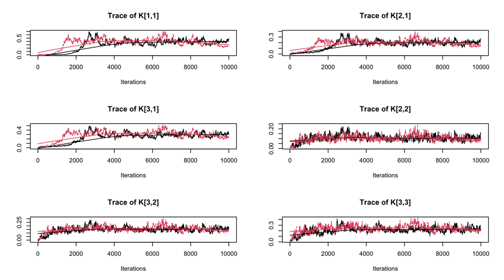

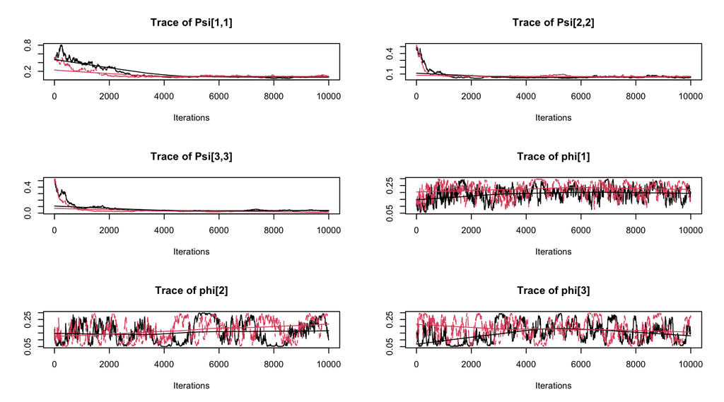

```r
library(coda)
par(mfrow=c(1,2))
plot(mcmc.list(m.1$p.theta.samples, m.2$p.theta.samples), density=FALSE)
```

### Obtaining posterior estimates

We could also obtain the range estimated using the posterior samples.

```r
### spMvLM-range
burn.in <- 0.75*n.samples
p.theta.samples <- as.matrix(window(mcmc.list(m.1$p.theta.samples, m.2$p.theta.samples), window=burn.in))
n.samples <- nrow(p.theta.samples)

fn <- function(d, a, phi){
  0.05 - sum(a^2*exp(-phi*d))/sum(a^2)
}

get.A <- function(K, q){
  A <- matrix(0, q, q)
  A[lower.tri(A,TRUE)] <- K
  A[upper.tri(A,FALSE)] <- t(A)[upper.tri(A,FALSE)]
  t(chol(A))
}

eff.range <- matrix(0, 3, n.samples)

for(s in 1:n.samples){
  A <- get.A(p.theta.samples[s, c("K[1,1]","K[2,1]","K[3,1]","K[2,2]","K[3,2]","K[3,3]")], q)
  phi <- p.theta.samples[s, c("phi[1]", "phi[2]", "phi[3]")]

  for(r in 1:q){
    eff.range[r,s] <- uniroot(fn, lower=0, upper=1000, tol=1e-15, a=A[i,1:r], phi=phi[1:r])$root
  }
}

rownames(eff.range) <- paste("Eff. range ",1:q,sep="")

round(summary(mcmc(cbind(p.theta.samples, t(eff.range))))$quantiles[,c(1,3,5)],3)
```

```
##                2.5%    50%  97.5%
## K[1,1]        0.006  0.372  0.584
## K[2,1]        0.012  0.193  0.303
## K[3,1]        0.020  0.287  0.430
## K[2,2]        0.022  0.104  0.169
## K[3,2]        0.037  0.152  0.231
## K[3,3]        0.072  0.227  0.342
## Psi[1,1]      0.043  0.086  0.495
## Psi[2,2]      0.039  0.060  0.263
## Psi[3,3]      0.012  0.034  0.273
## phi[1]        0.093  0.209  0.291
## phi[2]        0.053  0.158  0.291
## phi[3]        0.056  0.163  0.292
## Eff. range 1 10.278 14.320 32.086
## Eff. range 2 10.296 14.400 32.858
## Eff. range 3 10.324 14.422 32.992
```

We can also recover the nutrient concentration random spatial effects using `spRecover` and compare them with the residual image plots from a non-spatial regression.

```r
### spatial effects

Ca.resids <- resid(lm(Ca~1, data=log.nut))
K.resids <- resid(lm(K~1, data=log.nut))
Mg.resids <- resid(lm(Mg~1, data=log.nut))

m.1 <- spRecover(m.1, start=burn.in, thin=10)
```

```
## -------------------------------------------------
##      Recovering beta and w
## -------------------------------------------------
## Sampled: 99 of 251, 39.44%
## Sampled: 199 of 251, 79.28%
```

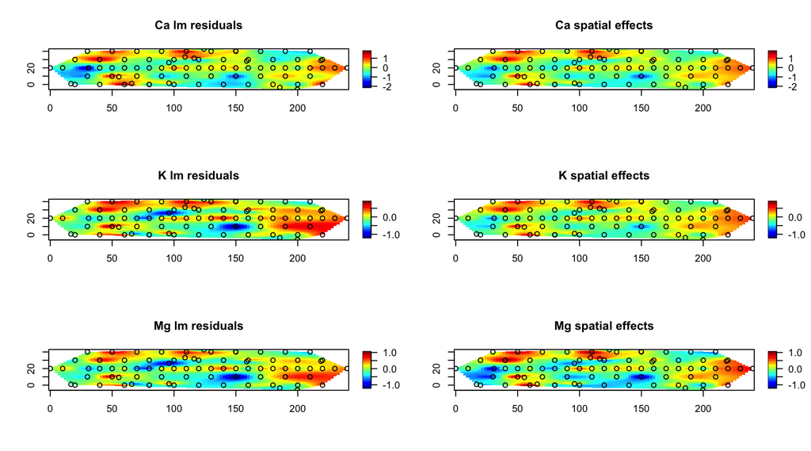

```r
w <- rowMeans(m.1$p.w.recover.samples)
w.Ca <- w[seq(1,length(w),q)]
w.K <- w[seq(2,length(w),q)]
w.Mg <- w[seq(3,length(w),q)]

res <- 100
par(mfrow=c(3,2))
surf.r <- mba.surf(cbind(coords,Ca.resids), no.X=res, no.Y=res, extend=FALSE)$xyz.est
surf.w <- mba.surf(cbind(coords,w.Ca), no.X=res, no.Y=res, extend=FALSE)$xyz.est
z.lim <- range(c(surf.r[["z"]], surf.w[["z"]]), na.rm=TRUE)

image.plot(surf.r, zlim=z.lim, main="Ca lm residuals"); points(coords)
image.plot(surf.w, zlim=z.lim, main="Ca spatial effects"); points(coords)

surf.r <- mba.surf(cbind(coords,K.resids), no.X=res, no.Y=res, extend=FALSE)$xyz.est
surf.w <- mba.surf(cbind(coords,w.K), no.X=res, no.Y=res, extend=FALSE)$xyz.est
z.lim <- range(c(surf.r[["z"]], surf.w[["z"]]), na.rm=TRUE)

image.plot(surf.r, zlim=z.lim, main="K lm residuals");points(coords)
image.plot(surf.w, zlim=z.lim, main="K spatial effects");points(coords)

surf.r <- mba.surf(cbind(coords,K.resids), no.X=res, no.Y=res, extend=FALSE)$xyz.est
surf.w <- mba.surf(cbind(coords,w.Mg), no.X=res, no.Y=res, extend=FALSE)$xyz.est
z.lim <- range(c(surf.r[["z"]], surf.w[["z"]]), na.rm=TRUE)

image.plot(surf.r, zlim=z.lim, main="Mg lm residuals"); points(coords)
image.plot(surf.w, zlim=z.lim, main="Mg spatial effects"); points(coords)
```

```r
### prediction
x.range <- range(coords[,1])
y.range <- range(coords[,2])

pred.coords <- expand.grid(seq(x.range[1], x.range[2], by=4),
                           seq(y.range[1], y.range[2], by=4))

m <- nrow(pred.coords)

pred.X <- mkMvX(list(matrix(1,m,1), matrix(1,m,1), matrix(1,m,1)))

nut.pred <- spPredict(m.1, start=burn.in, thin=10, pred.coords=pred.coords, pred.covars=pred.X)
```

```
## -------------------------------------------------
##      Recovering beta
## -------------------------------------------------
## Sampled: 99 of 251, 39.44%
## Sampled: 199 of 251, 79.28%
## ----------------------------------------
##  General model description
## ----------------------------------------
## Model fit with 80 observations.
##
## Prediction at 793 locations.
##
## Number of covariates 3 (including intercept if specified).
##
## Using the exponential spatial correlation model.
##
## -------------------------------------------------
##      Sampling
## -------------------------------------------------
## Sampled: 100 of 251, 39.44%
## Sampled: 200 of 251, 79.28%
```

We can produce an interpolated image plot for the posterior predictive mean and standard deviation. We first extract the posterior predictive means and standard deviations for each location.

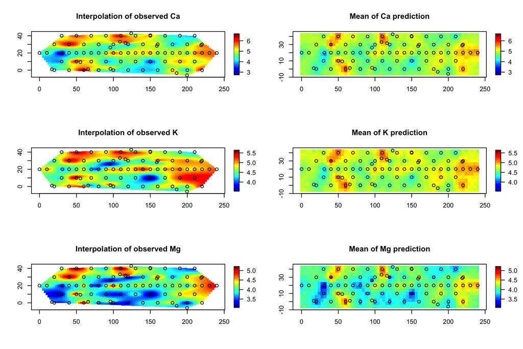

```r
### predicative means
y.pred.mu <- apply(nut.pred$p.y.predictive.samples, 1, mean)
y.pred.sd <- apply(nut.pred$p.y.predictive.samples, 1, sd)

Ca.pred.mu <- y.pred.mu[seq(1,length(y.pred.mu),q)]
K.pred.mu <- y.pred.mu[seq(2,length(y.pred.mu),q)]
Mg.pred.mu <- y.pred.mu[seq(3,length(y.pred.mu),q)]

Ca.pred.sd <- y.pred.sd[seq(1,length(y.pred.sd),q)]
K.pred.sd <- y.pred.sd[seq(2,length(y.pred.sd),q)]
Mg.pred.sd <- y.pred.sd[seq(3,length(y.pred.sd),q)]

nut.pred.grid <- as.data.frame(list(x=pred.coords[,1], y=pred.coords[,2],
                                     Ca.mu=Ca.pred.mu, K.mu=K.pred.mu, Mg.mu=Mg.pred.mu,
                                     Ca.sd=Ca.pred.sd, K.sd=K.pred.sd, Mg.sd=Mg.pred.sd))

library(sp)
coordinates(nut.pred.grid) <- c("x", "y") # promote to SpatialPointsDataFrame
gridded(nut.pred.grid) <- TRUE            # promote to SpatialGridDataFrame

toImage <- function(x){as.image.SpatialGridDataFrame(x)}

res <- 100
par(mfrow=c(3,2))

surf <- mba.surf(cbind(coords,log.nut[,"Ca"]), no.X=res, no.Y=res, extend=FALSE)$xyz.est
z.lim <- range(surf[["z"]], na.rm=TRUE)
image.plot(surf, xaxs = "r", yaxs = "r", main="Interpolation of observed Ca")
points(coords)

image.plot(toImage(nut.pred.grid["Ca.mu"]), xaxs = "r", yaxs = "r", zlim=z.lim, main="Mean of Ca prediction")
points(coords)

surf <- mba.surf(cbind(coords,log.nut[,"K"]), no.X=res, no.Y=res, extend=FALSE)$xyz.est
z.lim <- range(surf[["z"]], na.rm=TRUE)
image.plot(surf, xaxs = "r", yaxs = "r", main="Interpolation of observed K")
points(coords)

image.plot(toImage(nut.pred.grid["K.mu"]), xaxs = "r", yaxs = "r", zlim=z.lim, main="Mean of K prediction")
points(coords)

surf <- mba.surf(cbind(coords,log.nut[,"Mg"]), no.X=res, no.Y=res, extend=FALSE)$xyz.est
z.lim <- range(surf[["z"]], na.rm=TRUE)
image.plot(surf, xaxs = "r", yaxs = "r", main="Interpolation of observed Mg")
points(coords)

image.plot(toImage(nut.pred.grid["Mg.mu"]), xaxs = "r", yaxs = "r", zlim=z.lim, main="Mean of Mg prediction")
points(coords)
```

Similarly, we can obtain the corresponding plots for the predictive standard deviations.

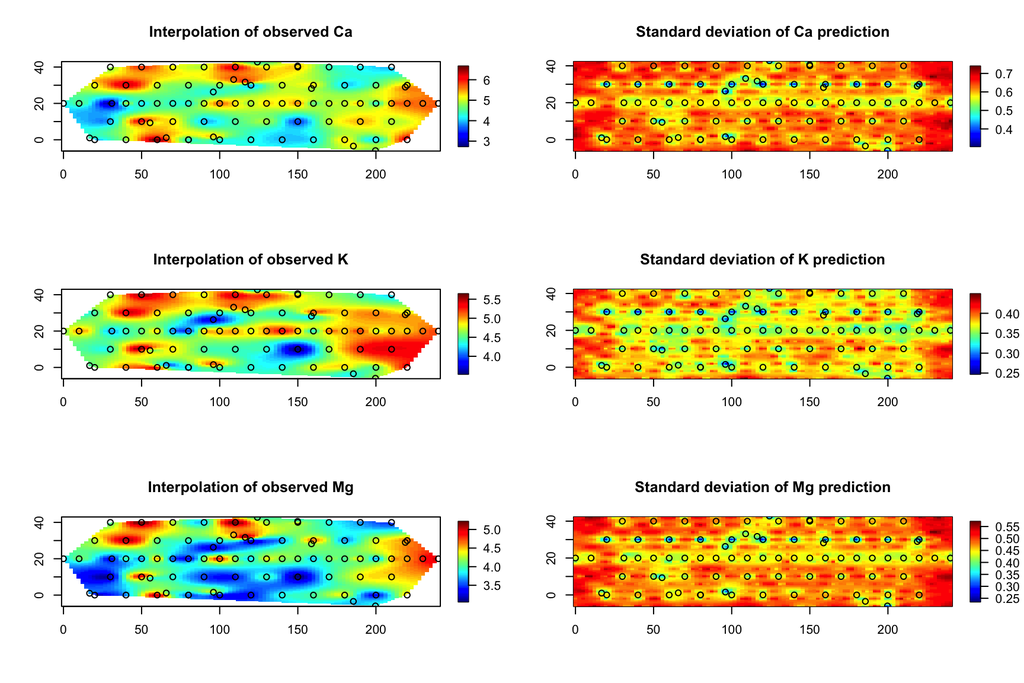

```r
### predicative standard deviations
par(mfrow=c(3,2))
surf <- mba.surf(cbind(coords,log.nut[,"Ca"]), no.X=res, no.Y=res, extend=FALSE)$xyz.est
image.plot(surf, main="Interpolation of observed Ca")
points(coords)

surf <- mba.surf(cbind(pred.coords,Ca.pred.sd), no.X=res, no.Y=res, extend=FALSE)$xyz.est
image.plot(surf, main="Standard deviation of Ca prediction")
points(coords)

surf <- mba.surf(cbind(coords,log.nut[,"K"]), no.X=res, no.Y=res, extend=FALSE)$xyz.est
image.plot(surf, main="Interpolation of observed K")
points(coords)

surf <- mba.surf(cbind(pred.coords,K.pred.sd), no.X=res, no.Y=res, extend=FALSE)$xyz.est
image.plot(surf, main="Standard deviation of K prediction")
points(coords)

surf <- mba.surf(cbind(coords,log.nut[,"Mg"]), no.X=res, no.Y=res, extend=FALSE)$xyz.est
image.plot(surf, main="Interpolation of observed Mg")
points(coords)

surf <- mba.surf(cbind(pred.coords,Mg.pred.sd), no.X=res, no.Y=res, extend=FALSE)$xyz.est
image.plot(surf, main="Standard deviation of Mg prediction")
points(coords)
```